# SElshahawy_Assign_13

Salma Elshahawy

4/28/2020

## Question_1

Use integration by substitution to solve the integral below.

$\int{4e^{-7x}dx}$

$$=\int { \frac { 4\times -7 }{ -7 } } { e }^{ u }\quad du$$
$$=\frac { -4 }{ 7 } { e }^{ -7x }\quad +\quad c$$
where c is a constant.

## Question_2

Biologists are treating a pond contaminated with bacteria. The level of contamination is changing at a rate of $\frac{dN}{dt} = -\frac{3150}{t^4}-220$ bacteria per cubic centimeter per day, where t is the number of days since treatment began. Find a function $N(t)$ to estimate the level of contamination if the level after 1 day was 6530 bacteria per cubic centimeter.

$$\frac{dN}{dt} = N'(t) = \frac{-3150}{t^4}-220$$
To find $N(t)$ we find the integration

$$N(t) = \int{(\frac{-3150}{t^4}-220) dt}$$
$$N(t)= \frac{1050}{t^3}-220t+C$$
back substitute with the $N(t) = 6530$ where t = 1 to find C

$$6530= \frac{1050}{(1)^3}-220(1)+C$$
$$5700= C$$

The contamination level could be presented by

$$N(t)= \frac{1050}{t^3}-220t+5700$$

## Question_3

```r
eq = function(x) {
  return (2*x - 9)
}
area = integrate(eq, 4.5, 8.5)
print(area)
```

```
## 16 with absolute error < 1.8e-13
```

## Question_4

Find the area of the region bounded by the graphs of the given equations.

$$y_1 = x_1^2 - 2x_1-2$$
$$y_2 = x_2 + 2$$

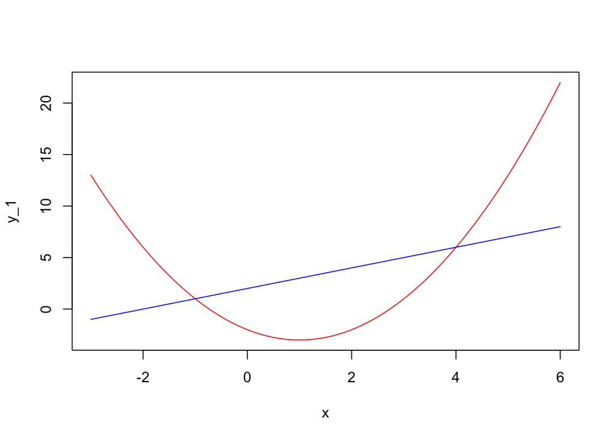

```r
y_1 = function(x) {
  return(x^2 - 2*x - 2)
}

y_2 = function(x) {
  return(x + 2)
}

plot(y_1, -3, 6, col = 'red')
plot(y_2, -3, 6, add=TRUE, col = 'blue')
```

We need to solve the two equations for x to get the intersection points, (the intersection points are the bounds for the integral)

$$x^{2}-2x-2=x+2$$

$$x^{2}-3x-4=0$$
$$x=4 \quad or \quad x=-1$$

$$A=\int _{ { \, a } }^{ { \, b } }{ { \left( \begin{array}{c} { { upper } } \\ { { function } } \end{array} \right) -\left( \begin{array}{c} { { lower } } \\ { { function } } \end{array} \right) \, dx } }$$

```r
# upper function is the y_2, lower function is the y_1
area_1 <- integrate(y_1, -1, 4)
area_2 <- integrate(y_2, -1, 4)
area = (area_2$value - area_1$value)
print(as.numeric(area))
```

```
## [1] 20.83333
```

## Question_5

A beauty supply store expects to sell 110 flat irons during the next year. It costs $3.75 to store one flat iron for one year. There is a fixed cost of $8.25 for each order. Find the lot size and the number of orders per year that will minimize inventory costs.

#of orders per year = n lot size = 110/n cost = lot size * store cost + fixed cost * n cost = 110/n

assume half of the inventory are in stock

$$cost = \frac { 110 }{ 2n } \times 3.75\quad +\quad 8.25n\\$$
$$cost = \frac { 206.25 }{ n } \quad +\quad 8.25n\\$$
take first integral for n

$$\int { cost } \quad =\quad \int { \frac { 206.25 }{ n } } +\quad 8.25n$$
Now we can get the number of orders per year that will minimize the cost which is zero

$$\quad -\frac { 206.25 }{ { n }^{ 2 } } \quad +\quad 8.25\quad =\quad 0$$

Solve for n we get that $n = 5$, $lot size = 22$

## Question_6

Use integration by parts to solve the integral below.
$$\int{ln(9x) \cdot x^6 dx}$$

$$=\frac { 1 }{ 7 } x^{ 7 }\times ln(9x)-\int { \frac { 1 }{ 7 } x^{ 7 }\times \frac { 1 }{ x } dx } \\ =\frac { 1 }{ 7 } x^{ 7 }\times ln(9x)-\int { \frac { 1 }{ 7 } x^{ 6 }dx } \\ =\frac { 7 }{ 49 } x^{ 7 }\times ln(9x)-\frac { 1 }{ 49 } x^{ 7 }+c\\ =\frac { 1 }{ 49 } x^{ 7 }(7ln(9x)-1)+c\\$$

## Question_7

Determine whether $f(x)$ is a probability density function on the interval [1,e6]. If not, determine the value of the definite integral. $f(x) = \frac{1}{6x}$

$$\int _{ 1 }^{ e^{ 6 } } \frac { 1 }{ 6x } dx\quad =\quad \frac { 1 }{ 6 } ln(x)|_{ 1 }^{ e^{ 6 } }\\ =\frac { 1 }{ 6 } ln(e^{ 6 })\quad -\quad \frac { 1 }{ 6 } ln(1)\\ =\frac { 1 }{ 6 } \times 6\quad \\ =1$$
The definite integral of the function on interval [1,e6] is 1. Additionally, if x>0, then f(x)>0, so for this interval f(x)>0. As long as f(x)=0 outside of the given interval, this satisfies PDF requirements and this function is a probability density function.